BUAN 6359.003 - Advanced Statistics for Data Science - Final Test

Prriyamvradha Parthasarathi - pxp220005

```r
library(readxl)
library(tidyr)
library(moments)
library(dplyr)
```

**#################################################**

Problem 1: Does Confidence Interval work?  
We’ll generate a population, get a sample from it, create a Confidence Interval using this sample, and then check if our Confidence interval has the Population parameter. Use a 4-digit number (nnnn) of your choice to set the seed using this command: set.seed=nnnn Generate a Normal distribution problem with N = 2,500, Mean =180, and Std dev = 30. Round it off to 1 decimal place Find the mean of this population.Now, from this population, after setting the same seed again, draw a random sample of size n = 30.

```r
rm(list=ls()) ;

# Set Seed
set.seed(1234)

# Generating a Normal distribution
ND <- round(rnorm(2500,180,30),1);

# Mean of the Population.
Population_Mean <- mean(ND)

# Setting same seed again,
set.seed(1234)

# Random sample of size n = 30.
Sample <- sample(ND,30)

# Mean of the Sample
Sample_Mean <- mean(Sample)

# Standard Deviation of the Sample
Sample_Sd <- sd(Sample)

# Standard Error of the Sample
Standard_Error <- Sample_Sd/sqrt(30)

# t-score for a Confidence level of 84.65%.
n=30
t <- qt(0.07675,n-1,lower.tail = FALSE)

# Lower and Upper limits of the Confidence interval
Lower_Tail <- Sample_Mean - t*Standard_Error
Upper_Tail <- Sample_Mean + t*Standard_Error

# If statement to see if the population mean falls within the Confidence interval
if(Population_Mean >= Lower_Tail & Population_Mean <= Upper_Tail)
    {cat("Population Mean is within the Confidence Interval")} else
    {cat("Population Mean is not within the Confidence Interval")}
```

```
## Population Mean is within the Confidence Interval
```

**Problem 1 Answers**

**a.** Find the mean and the std error of this sample: **Sample Mean:** **175.5133333** and **Standard Error:** **5.9241755**

**b.** Get the proper t-score for a Confidence level of 84.65%: **t-score:** **1.4656614**

**c.** Find the lower and upper limits of the Confidence interval: **Lower limit:** **166.8304977** **Upper Limit:** **184.196169**

**d.** Use If statement to see if the population mean falls within the Confidence interval. Get the appropriate output from the R code: **Population Mean is within the Confidence Interval**

**#################################################**

**Problem 2: (Set-1)**  
**Three anti-bacteria creams were used on three age groups.The number of hours before the medicines started to show a** **noticeable effect are recorded in the table.Assume Alpha = 0.05**

```r
rm(list=ls()) ;

# Read Set-1 from the Excel
prob_2<-data.frame(read_excel("F22-6359-Test-3.xlsx", sheet="Set-1"))

# Create individual vectors.   rep command rep("Young",30) will repeat Young 30 times.
v1<-data.frame(Hours = prob_2[, 2], Medicine = prob_2[, 1], Age=rep("Young",30))
v2<-data.frame(Hours = prob_2[, 3], Medicine = prob_2[, 1], Age=rep("Middle_Age",30))
v3<-data.frame(Hours = prob_2[, 4], Medicine = prob_2[, 1], Age=rep("Senior",30))

# Rename columns
names(v1)[1] <- 'Hours'
names(v2)[1] <- names(v1)[1]
names(v3)[1] <- names(v1)[1]

# Combine everything and create a new dataset
data1=rbind(v1, v2, v3)
attach(data1)

# a.  Run this as an ANOVA 2-factor  R program.
a1 <- aov(Hours~Medicine+Age+Medicine:Age)
summary(a1)
```

```
##              Df Sum Sq Mean Sq F value  Pr(>F)
## Medicine      2   8414    4207   5.950 0.00388 **
## Age           2    661     331   0.468 0.62814
## Medicine:Age  4  10022    2506   3.543 0.01026 *
## Residuals    81  57280     707
## ---
## Signif. codes:  0 '***' 0.001 '**' 0.01 '*' 0.05 '.' 0.1 ' ' 1
```

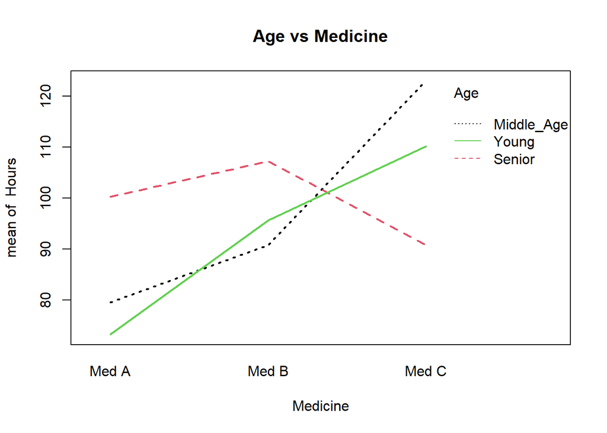

```r
P_Age <- summary(a1)[[1]][[2,"Pr(>F)"]]
P_Medicine <- summary(a1)[[1]][[1,"Pr(>F)"]]
F_Medicine <- summary(a1)[[1]][[1,"F value"]]

# c.  Also draw the interaction graph to show the interaction between the two factors.
interaction.plot (Medicine, Age, Hours, lwd = 2,  col=1:3, main="Age vs Medicine")
```

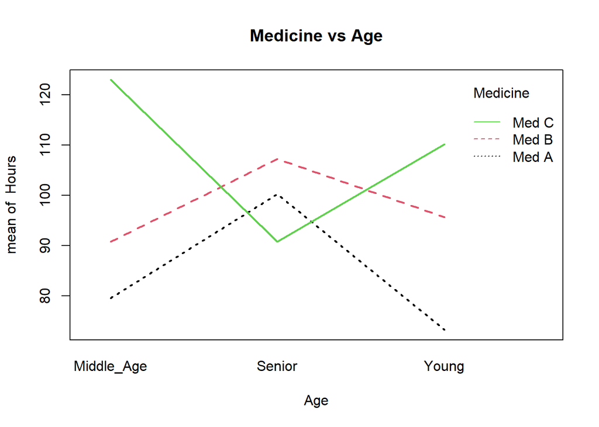

```r
interaction.plot (Age, Medicine, Hours, lwd = 2,  col=1:3, main="Medicine vs Age")
```

**Problem 2 Answers**

**QUESTION 1:** For Set 1, the P-value for Age is: **P-value for Age:** **0.6281449**

**QUESTION 2:** For Set 1, what is the P-value for Medicine?: **P-value for Medicine:** **0.0038831**

**QUESTION 3:** For Set 1, is there an interaction between Medicine and Age: **There is interaction**

**QUESTION 4:** For Set 1, what is the F-stat for medicine ?: **F-stat:** **5.9495318**

**QUESTION 5:** Does Age have any effect on the number of hours before the medicines start work?: **No**

**QUESTION 6:** For Set 1, can you say that the medicines behave differently in regards to the time it takes to show an effect?: **Yes because we reject the Null hypothesis**

**#################################################**

**Problem 3: (Set-2) Two sample t-test** **Automobile Insurance companies consider many factors including the miles driven by a driver and the gender.**  
**The dataset consists of the reported miles (in thousands) driven by young drivers (25 years or less)** **in the previous year. One insurance company wants to know if there are any difference between the two genders.**

```r
rm(list=ls()) ;

# Read Set-2 from the Excel
prob_3 <-read_excel("F22-6359-Test-3.xlsx", sheet="Set-2")

# a.  Do a variance test to see if the two variances are equal.
var.test(Distance~Gender, data = prob_3)
```

```
##
##  F test to compare two variances
##
## data:  Distance by Gender
## F = 1.0246, num df = 99, denom df = 99, p-value = 0.904
## alternative hypothesis: true ratio of variances is not equal to 1
## 95 percent confidence interval:
##  0.6893942 1.5227966
## sample estimates:
## ratio of variances
##           1.024601
```

```r
var_test_pval <- var.test(Distance~Gender, data = prob_3)$p.value

# b.  Do the appropriate t-test at Alpha = 5%.
t.test(Distance~Gender, var.equal= TRUE, data = prob_3)
```

```
##
##  Two Sample t-test
##
## data:  Distance by Gender
## t = -1.4193, df = 198, p-value = 0.1574
## alternative hypothesis: true difference in means between group Female and group Male is not equal to 0
## 95 percent confidence interval:
##  -1.3810709  0.2250709
## sample estimates:
## mean in group Female   mean in group Male
##                9.677               10.255
```

```r
t_test_pval <- t.test(Distance~Gender, var.equal= TRUE, data = prob_3)$p.value
t_test_tstat <- t.test(Distance~Gender, var.equal= TRUE, data = prob_3)$statistic
```

**Problem 3 Answers**

**QUESTION 7:** For Set 2, what is the p-value from the Variance test?: **P-value for Variance test:** **0.9040073**

**QUESTION 8:** For Set 2, after calculating Variance what are you observations?: **Variances are equal**

**QUESTION 9:** What is the Null Hypothesis for Set-2?: **Mean male = Mean female**

**QUESTION 10:** For Set 2, what is the p-value for the t-test?: **P-value for t-test:** **0.1573739**

**QUESTION 11:** For Set 2, what is the t-statistics?: **t-statistics:** **-1.4193343**

**QUESTION 12:** For Set 2, what decision is made after calculating T-test?: **There is no difference between the male and the female drivers**

**#################################################**

**Problem 4 (Set-3)** **A bank has collected a sample and is trying to see how various factors impact it’s loan approvals.** **Divide Credit Scores by 10 and incomes by 1000 (in R) and perform Logistics Regression.**

```r
rm(list=ls()) ;

# Read Set-3 from the Excel
prob_4<-read_excel("F22-6359-Test-3.xlsx", sheet = "Set-3")

# Rename the variables
names(prob_4)[1] <- 'Loan.Approved'
names(prob_4)[2] <- 'Credit.scores'
names(prob_4)[3] <- 'Income'
names(prob_4)[4] <- 'Neighborhood.income'

# Divide Credit Scores by 10 and incomes by 1000
prob_4$Credit.scores<- prob_4$Credit.scores/10
prob_4$Income<- prob_4$Income/1000
prob_4$Neighborhood.income<- prob_4$Neighborhood.income/1000

attach(prob_4)

# Logistic Regression
Loan <-glm(Loan.Approved ~ Credit.scores + Income + Neighborhood.income, family="binomial")
summary(Loan)
```

```
##
## Call:
## glm(formula = Loan.Approved ~ Credit.scores + Income + Neighborhood.income,
##     family = "binomial")
##
## Deviance Residuals:
##     Min       1Q   Median       3Q      Max
## -1.5276  -0.9104  -0.6602   1.1599   2.1914
##
## Coefficients:
##                     Estimate Std. Error z value Pr(>|z|)
## (Intercept)         -9.23814    1.54545  -5.978 2.26e-09 ***
## Credit.scores        0.03141    0.01088   2.888  0.00387 **
## Income               0.04892    0.02028   2.412  0.01589 *
## Neighborhood.income  0.09551    0.02615   3.653  0.00026 ***
## ---
## Signif. codes:  0 '***' 0.001 '**' 0.01 '*' 0.05 '.' 0.1 ' ' 1
##
## (Dispersion parameter for binomial family taken to be 1)
##
##     Null deviance: 510.13  on 399  degrees of freedom
## Residual deviance: 468.78  on 396  degrees of freedom
## AIC: 476.78
##
## Number of Fisher Scoring iterations: 4
```

```r
# Maximum likelihood estimates of the parameters
RegOut<-c(coef(Loan))

# Neighborhood with income of 40192
odd40192<-exp(RegOut[1]+RegOut[2]+RegOut[3]+RegOut[4]*40.192)
# Neighborhood income of 46569
Odd46569<-exp(RegOut[1]+RegOut[2]+RegOut[3]+RegOut[4]*46.569)
# odds of loan approval for Neighborhood with income of 40192 vs Neighborhood income of 46569
odds_ratio <- odd40192/Odd46569

# Loan approval for a person whose credit score is 728, income is 61653 and lives in a neighborhood whose income is 35436
odds<-exp(RegOut[1]+RegOut[2]*72.8+RegOut[3]*61.653+RegOut[4]*35.436)
#Probability
probabbility <- odds/(odds+1)

# Loan approval for a person whose credit score is 716, income is 56759 and whose income is 40746
odds1<-exp(RegOut[1]+RegOut[2]*71.6+RegOut[3]*56.759+RegOut[4]*40.746)
```

**Problem 4 Answers**

**QUESTION 13:** For Set 3, what are the odds of loan approval for a person who lives in a neighborhood with income of 40192 vs someone with the neighborhood income of 46569 assuming everything else being equal?: **Odds ratio:** **0.5438447**

**QUESTION 14:** For Set 3, what is the probability of loan approval for a person whose credit score is 728, income is 61653 and lives in a neighborhood whose income is 35436?: **Probability:** **0.3656949**

**QUESTION 15:** For Set 3, what are the Odds of loan approval for a person whose credit score is 716, income is 56759 and lives in a neighborhood whose income is 40746: **Odds:** **0.7256806**

**QUESTION 16:** For the Logistics Problem in Set 3, what is the coefficient of Income as calculated by R? : **Coefficient of Income:** **0.0489162**

**QUESTION 17:** For the Logistics Problem in Set 3, what is the coefficient of Credit Scores as calculated by R?: **Coefficient of Credit Scores:** **0.0314141**

**QUESTION 18:** For the Logistics Problem in Set 3, what is the Intercept calculated by R? : **Intercept:** **-9.2381363**

**#################################################**

**Problem 5 (Set-4)** **You’ve picked up a bunch of rocks from a rocky beach and want to estimate the weight of all the** **rocks at the beach with a Confidence level of 93.47%.**

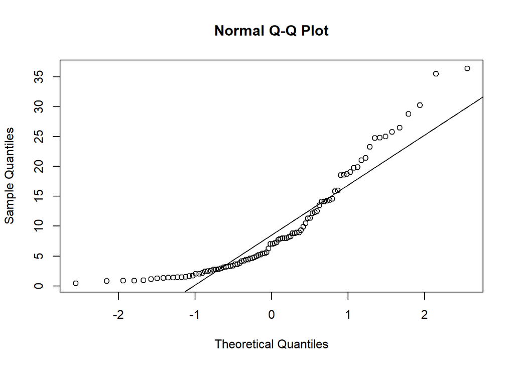

```r
rm(list=ls()) ;

# Read Set-4 from the Excel
prob_5 <-read_excel("F22-6359-Test-3.xlsx", sheet="Set-4")
attach(prob_5)

# a.  Plot the qqline and box plot of the data.  Also get the skewness.  What is your conclusion about the distribution being normal?
qqnorm(Weight)
qqline(Weight)
```

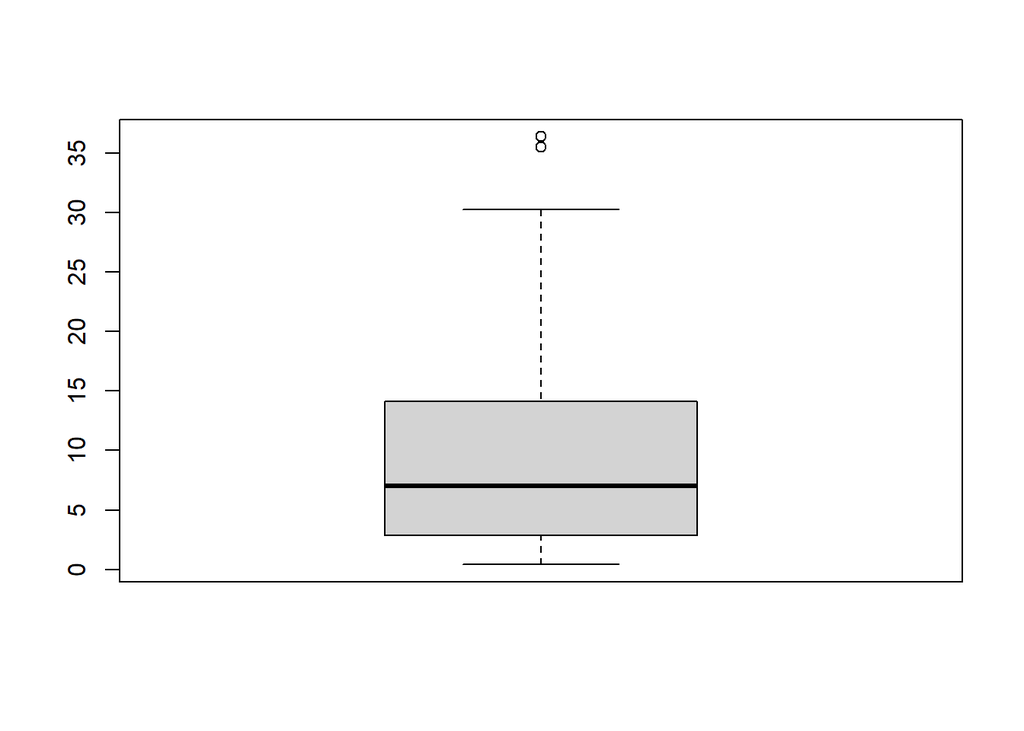

```r
boxplot(Weight)
```

```r
# skewness Before log Transformation?
skewness(Weight)
```

```
## [1] 1.233937
```

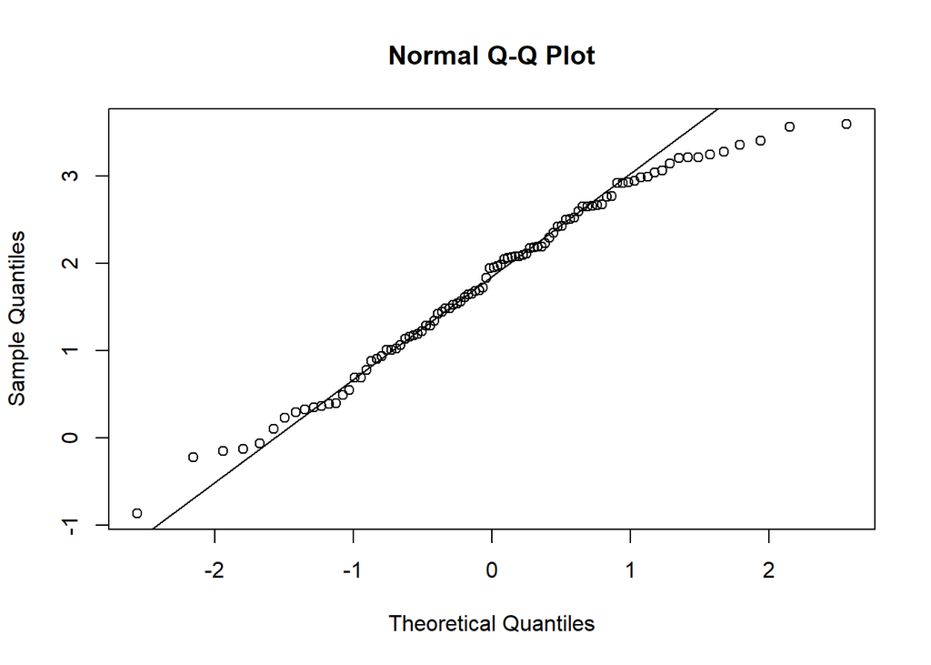

```r
# b.  Do a log transformation (base e) and perform the steps in a.  What's your conclusion?  Use Log transformed data for the following questions.
log_data <- log(prob_5$Weight,base = exp(1))
qqnorm(log_data)
qqline(log_data)
```

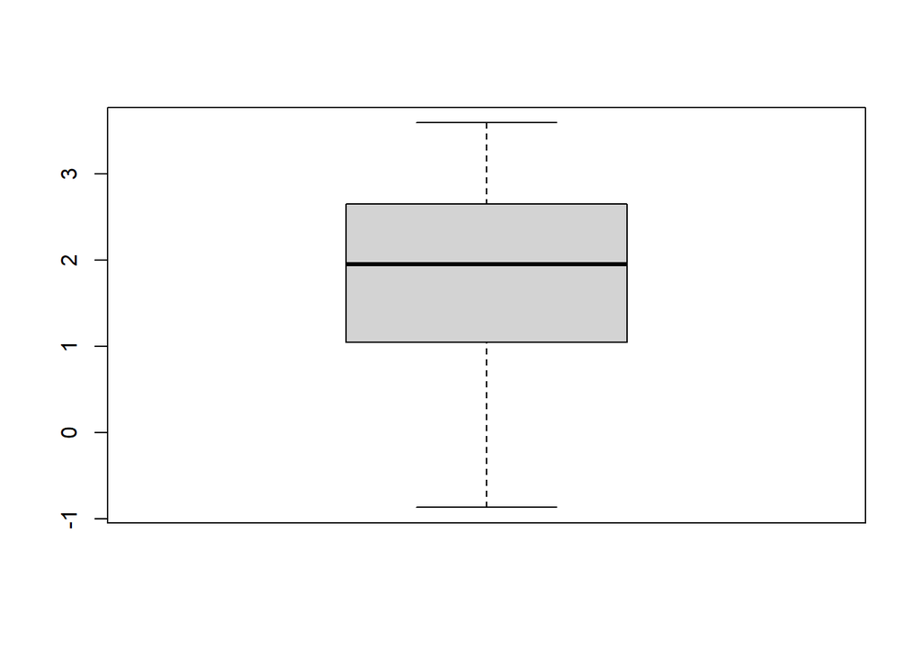

```r
boxplot(log_data)
```

```r
skewness(log_data)
```

```
## [1] -0.2867998
```

```r
# c.  What is the mean, Std dev, and the sample size?
mean_prob5 <- mean(log_data); mean_prob5
```

```
## [1] 1.79195
```

```r
sd_prob5 <- sd(log_data); sd_prob5
```

```
## [1] 1.026756
```

```r
sample_size_prob5 <- length(log_data); sample_size_prob5
```

```
## [1] 96
```

```r
# d.  Find std error using the std error formula we've discussed.
std_error_prob5 <- (sd_prob5/sqrt(sample_size_prob5)); std_error_prob5
```

```
## [1] 0.1047928
```

```r
# e.  Find the t-score for the 93.47% confidence interval.
t_score_prob5  <- qt(0.03265,sample_size_prob5-1,lower.tail = FALSE); t_score_prob5
```

```
## [1] 1.864775
```

```r
# f.  Use this t-score, sample mean, std error to get the upper and lower limit of the Confidence Interval.  Use the formula we've discussed.
Lower_Tail_prob5 <- mean_prob5 - t_score_prob5*std_error_prob5; Lower_Tail_prob5
```

```
## [1] 1.596535
```

```r
Upper_Tail_prob5 <- mean_prob5 + t_score_prob5*std_error_prob5; Upper_Tail_prob5
```

```
## [1] 1.987366
```

```r
# g.  Do reverse transformation to get the Confidence Interval in Ounces.
Upper_Tail_rev <- exp(Upper_Tail_prob5); Upper_Tail_rev
```

```
## [1] 7.296286
```

```r
Lower_Tail_rev <- exp(Lower_Tail_prob5); Lower_Tail_rev
```

```
## [1] 4.935902
```

**Problem 5 Answers**

**QUESTION 19:** For Set 4, what is the mean of the log-transformed data? : **Mean:** **1.7919505**

**QUESTION 20:** For Set 4, what is the skewness Before log Transformation? : **Skewness:** **1.2339372**

**QUESTION 21:** For Set 4, calculate Skewness after log transformation? : **Skewness:** **-0.2867998**

**QUESTION 22:** For Set 4, calculate the standard Deviation after log transformation :**Standard Deviation:** **1.0267557**

**QUESTION 23:** For Set 4, what is the standard error? : **Standard Error:** **0.1047928**

**QUESTION 24:** For Set 4, what is the lower limit of Confidence Interval for a Confidence level of LCL? : **Lower Limit of CI:** **1.5965354**

**QUESTION 25:** For Set 4, calculate Upper Limit after reverse Transformation? : **Upper Limit:** **7.2962865**

**QUESTION 26:** For Set 4, what is the Lower Limit after reverse Transformation? : **Lower Limit:** **4.935902**

**#################################################**

**Problem 6 (Set-5)** **A random sample of 1100 U.S. adults were questioned regarding their political affiliation and opinion on a tax reform bill** **Perform a test to see if the political affiliation and their opinion on a tax reform bill are independent**

```r
rm(list=ls()) ;

# Read Set-5 from the Excel
prob_6 <- data.frame(read_excel("F22-6359-Test-3.xlsx", sheet="Set-5"))
# Get ChiSq Stats, P-values, etc. as required by the Online test.
chisq_prob_6 <- prob_6[1:3,2:4]
chisq.test(chisq_prob_6)
```

```
##
##  Pearson's Chi-squared test
##
## data:  chisq_prob_6
## X-squared = 8.9437, df = 4, p-value = 0.06252
```

```r
df <- chisq.test(chisq_prob_6)$parameter
Chi_Sq_Critical <- qchisq(p =0.05, df = 4, lower.tail =FALSE)
p_val <- chisq.test(chisq_prob_6)$p.value
```

**Problem 6 Answers**

**QUESTION 27:** For Set-5, what are the degrees of Freedom? : **Degrees of Freedom:** **4**

**QUESTION 28:** For Set-5, what is the ChiSq Critical? Assume Alpha = 5% : **ChiSq Critical:** **9.487729**

**QUESTION 29:** For Set-5, what is the P-Value? : **P-value:** **0.0625224**

**QUESTION 30:** For Set-5, what is the correct outcome? Assume Alpha = 5% : **The opinion on the Tax form doesn’t depend on the political affliation**